# Predicting Life Expectancy by Social Determinants of Health in the Midwest

# 1 Preliminaries

## 1.1 My Packages

```r
library(knitr)
library(rmdformats)

options(max.print="150"); opts_chunk$set(comment=NA); opts_knit$set(width=75)
```

```r
library(broom)
library(car)
library(equatiomatic)
library(gt)
library(gtExtras)
library(kableExtra)
library(ggrepel)
library(ggdist)
library(janitor)
library(naniar)
library(patchwork)
library(tidyverse)

theme_set(theme_bw())
```

## 1.2 Data Ingest

I’ll be using County Health Rankings 2022 data. The code below loads the data directly from the website.

```r
data_url <- "https://www.countyhealthrankings.org/sites/default/files/media/document/analytic_data2022.csv"

chr_2022_raw <- read_csv(data_url, skip = 1, guess_max = 4000,
                         show_col_types = FALSE)
```

# 2 Data Development

## 2.1 Selecting My Data

```r
chr_2022 <- chr_2022_raw |>
    filter(county_ranked == 1) |>
    filter(state %in% c( "KS", "MS", "ND", "OH")) |>
    select(fipscode, state, county,county_ranked,
           v147_rawvalue, v070_rawvalue, v069_rawvalue,
           v023_rawvalue, v063_rawvalue) |>
    rename(life_expectancy = v147_rawvalue,
           physical_inactivity = v070_rawvalue,
           some_college = v069_rawvalue,
           unemployment = v023_rawvalue,
           median_household_income = v063_rawvalue) |>
    mutate(physical_inactivity = 100*physical_inactivity,
           some_college = 100*some_college,
           unemployment = 100*unemployment)
```

## 2.2 Repairing the `fipscode` and factoring the `state`

```r
chr_2022 <- chr_2022 |>
    mutate(fipscode = str_pad(fipscode, 5, pad = "0"),
           state = factor(state))
```

### 2.2.1 Checking Initial Work

Given the “states” I selected, I should have 322 rows, since there are 322 counties across those states, and I should have 9 columns (variables).

```r
glimpse(chr_2022)
```

```
Rows: 322
Columns: 9
$ fipscode                <chr> "20001", "20003", "20005", "20007", "20009", "…
$ state                   <fct> KS, KS, KS, KS, KS, KS, KS, KS, KS, KS, KS, KS…
$ county                  <chr> "Allen County", "Anderson County", "Atchison C…
$ county_ranked           <dbl> 1, 1, 1, 1, 1, 1, 1, 1, 1, 1, 1, 1, 1, 1, 1, 1…
$ life_expectancy         <dbl> 76.29985, 76.49852, 77.67664, 75.51893, 76.888…
$ physical_inactivity     <dbl> 32.8, 31.2, 31.0, 31.6, 32.1, 31.3, 31.1, 28.3…
$ some_college            <dbl> 56.72932, 57.35476, 58.10965, 59.74166, 59.501…
$ unemployment            <dbl> 5.428661, 4.117647, 6.869895, 3.356282, 4.6345…
$ median_household_income <dbl> 48616, 53936, 56691, 52749, 51149, 49821, 4948…
```

Looks good. Checking to see that each of my states has the anticipated number of counties, too.

```r
chr_2022 |> tabyl(state) |> adorn_pct_formatting()
```

```
 state   n percent
    KS 104   32.3%
    MS  82   25.5%
    ND  48   14.9%
    OH  88   27.3%
```

Looks good too.

## 2.3 Creating Binary Categorical Variables

First, I will make a binary categorical variable using the `unemployment` variable.

### 2.3.1 Splitting into two categories based on the median

```r
chr_2022 <- chr_2022 |>
    mutate(temp1 = case_when(
                   unemployment < median(unemployment) ~ "low",
                   TRUE ~ "high"),
           temp1 = factor(temp1))

mosaic::favstats(unemployment ~ temp1, data = chr_2022) |>
    kable(digits = 3)
```

| temp1 | min | Q1 | median | Q3 | max | mean | sd | n | missing |
| --- | --- | --- | --- | --- | --- | --- | --- | --- | --- |
| high | 6.613 | 7.497 | 8.299 | 9.345 | 18.401 | 8.700 | 1.838 | 161 | 0 |
| low | 1.715 | 3.322 | 4.368 | 5.373 | 6.585 | 4.329 | 1.256 | 161 | 0 |

### 2.3.2 Cleaning up

```r
chr_2022 <- chr_2022 |>
    rename(unemp_cat = temp1)
```

Confirming I have added the `unemp_cat` column to the data.

```r
names(chr_2022)
```

```
 [1] "fipscode"                "state"
 [3] "county"                  "county_ranked"
 [5] "life_expectancy"         "physical_inactivity"
 [7] "some_college"            "unemployment"
 [9] "median_household_income" "unemp_cat"
```

Ensuring no new counties were added.

```r
nrow(chr_2022)
```

```
[1] 322
```

OK. Still looks fine.

## 2.4 Creating Multi-Category Variables

I’ll be selecting `median_household_income` as my multi-category variable.

### 2.4.1 Creating a Three-Category Variable

I’ll be using the`cut2` function from the `Hmisc` package to create three groups of equal size.

```r
chr_2022 <- chr_2022 |>
    mutate(temp2 = factor(Hmisc::cut2(median_household_income, g = 3)))

mosaic::favstats( median_household_income ~ temp2, data = chr_2022) |>
    kable(digits = 3)
```

| temp2 | min | Q1 | median | Q3 | max | mean | sd | n | missing |
| --- | --- | --- | --- | --- | --- | --- | --- | --- | --- |
| [30003, 49925) | 30003 | 38910.75 | 44646.5 | 47910.75 | 49821 | 43178.68 | 5538.511 | 108 | 0 |
| [49925, 58302) | 49925 | 51910.50 | 53936.0 | 56482.50 | 58256 | 54123.99 | 2580.915 | 107 | 0 |
| [58302,114423] | 58302 | 61828.50 | 66053.0 | 69528.00 | 114423 | 67546.13 | 8321.475 | 107 | 0 |

```r
chr_2022 <- chr_2022 |>
    mutate(temp2 = factor(Hmisc::cut2(median_household_income, g = 3)),
           temp3_newnames = fct_recode(temp2,
                                   low = "[30003, 49925)",
                                   middle = "[49925, 58302)",
                                   high = "[58302,114423]"))

mosaic::favstats(median_household_income ~ temp3_newnames, data = chr_2022) |>
    kable(digits = 3)
```

| temp3_newnames | min | Q1 | median | Q3 | max | mean | sd | n | missing |
| --- | --- | --- | --- | --- | --- | --- | --- | --- | --- |
| low | 30003 | 38910.75 | 44646.5 | 47910.75 | 49821 | 43178.68 | 5538.511 | 108 | 0 |
| middle | 49925 | 51910.50 | 53936.0 | 56482.50 | 58256 | 54123.99 | 2580.915 | 107 | 0 |
| high | 58302 | 61828.50 | 66053.0 | 69528.00 | 114423 | 67546.13 | 8321.475 | 107 | 0 |

### 2.4.2 Cleaning up

```r
chr_2022 <- chr_2022 |>
  rename(mhi_cat = temp3_newnames) |>
    select(-c(temp2))
```

## 2.5 Revise order of variables

I’d put `county_ranked` at the end of our list of variables, which we can do like this:

```r
chr_2022 <- chr_2022 |> relocate(county_ranked, .after = last_col())
```

This will make things easier to see when I print the tibble.

## 2.6 Three Important Checks

Checking for missing data.

```r
chr_2022 |>
    miss_var_summary()
```

```
# A tibble: 11 × 3
   variable                n_miss pct_miss
   <chr>                    <int>    <dbl>
 1 life_expectancy              3    0.932
 2 fipscode                     0    0
 3 state                        0    0
 4 county                       0    0
 5 physical_inactivity          0    0
 6 some_college                 0    0
 7 unemployment                 0    0
 8 median_household_income      0    0
 9 unemp_cat                    0    0
10 mhi_cat                      0    0
11 county_ranked                0    0
```

There is some missing data in one of the variables. I’ll be summarizing the missing data on life expectancy by states.

```r
mosaic::favstats(life_expectancy ~ state, data = chr_2022) |>
    select(state, n, missing) |>
    mutate(pct_available = 100*(n - missing)/n) |>
    kable()
```

| state | n | missing | pct_available |
| --- | --- | --- | --- |
| KS | 102 | 2 | 98.03922 |
| MS | 81 | 1 | 98.76543 |
| ND | 48 | 0 | 100.00000 |
| OH | 88 | 0 | 100.00000 |

Checking that the raw versions of each of my five selected variables have at least 10 distinct non-missing values.

```r
chr_2022|>
    summarize(across(life_expectancy:median_household_income, ~ n_distinct(.)))
```

```
# A tibble: 1 × 5
  life_expectancy physical_inactivity some_college unemployment median_househo…¹
            <int>               <int>        <int>        <int>            <int>
1             320                 157          322          321              320
# … with abbreviated variable name ¹median_household_income
```

OK. We’re fine there.

Checking that every level of the resulting factor includes at least 10 counties.

```r
chr_2022 |> tabyl(unemp_cat)
```

```
 unemp_cat   n percent
      high 161     0.5
       low 161     0.5
```

```r
chr_2022 |> tabyl(mhi_cat)
```

```
 mhi_cat   n   percent
     low 108 0.3354037
  middle 107 0.3322981
    high 107 0.3322981
```

OK. I have at least 10 counties in each category for each of the categorical variables that I created.

# 3 Our Analytic Tibble

## 3.1 Printing My Tibble

Creating a tibble to confirm I have 11 columns with 322 counties (rows).

```r
chr_2022
```

```
# A tibble: 322 × 11
   fipscode state county life_…¹ physi…² some_…³ unemp…⁴ media…⁵ unemp…⁶ mhi_cat
   <chr>    <fct> <chr>    <dbl>   <dbl>   <dbl>   <dbl>   <dbl> <fct>   <fct>
 1 20001    KS    Allen…    76.3    32.8    56.7    5.43   48616 low     low
 2 20003    KS    Ander…    76.5    31.2    57.4    4.12   53936 low     middle
 3 20005    KS    Atchi…    77.7    31      58.1    6.87   56691 high    middle
 4 20007    KS    Barbe…    75.5    31.6    59.7    3.36   52749 low     middle
 5 20009    KS    Barto…    76.9    32.1    59.5    4.63   51149 low     middle
 6 20011    KS    Bourb…    75.9    31.3    56.1    5.63   49821 low     low
 7 20013    KS    Brown…    74.3    31.1    62.6    4.46   49483 low     low
 8 20015    KS    Butle…    77.0    28.3    72.3    6.55   71827 low     high
 9 20017    KS    Chase…    80.4    29.7    68.2    5.53   57338 low     middle
10 20019    KS    Chaut…    77.0    34.2    60.6    6.07   43155 low     low
# … with 312 more rows, 1 more variable: county_ranked <dbl>, and abbreviated
#   variable names ¹life_expectancy, ²physical_inactivity, ³some_college,
#   ⁴unemployment, ⁵median_household_income, ⁶unemp_cat
```

Looks good so far. I think we are ready to go.

## 3.2 Summarizing our Tibble

Here’s where I’d run `describe` from the `Hmisc` package for one last check.

```r
Hmisc::describe(chr_2022)
```

```
chr_2022

 11  Variables      322  Observations
--------------------------------------------------------------------------------
fipscode
       n  missing distinct
     322        0      322

lowest : 20001 20003 20005 20007 20009, highest: 39167 39169 39171 39173 39175
--------------------------------------------------------------------------------
state
       n  missing distinct
     322        0        4

Value         KS    MS    ND    OH
Frequency    104    82    48    88
Proportion 0.323 0.255 0.149 0.273
--------------------------------------------------------------------------------
county
       n  missing distinct
     322        0      275

lowest : Adams County     Alcorn County    Allen County     Amite County     Anderson County
highest: Woodson County   Wyandot County   Wyandotte County Yalobusha County Yazoo County
--------------------------------------------------------------------------------
life_expectancy
       n  missing distinct     Info     Mean      Gmd      .05      .10
     319        3      319        1    76.07    3.563    70.20    72.31
     .25      .50      .75      .90      .95
   74.15    76.47    78.09    79.81    80.47

lowest : 64.70803 65.22172 66.00011 68.02538 68.14273
highest: 81.91107 83.34455 84.40416 87.10828 91.38325
--------------------------------------------------------------------------------
physical_inactivity
       n  missing distinct     Info     Mean      Gmd      .05      .10
     322        0      157        1    33.39    6.609    26.71    27.61
     .25      .50      .75      .90      .95
   29.02    31.35    37.27    42.58    46.67

```

[output cut: 37 more lines]

```
       n  missing distinct
     322        0        3

Value         low middle   high
Frequency     108    107    107
Proportion  0.335  0.332  0.332
--------------------------------------------------------------------------------
county_ranked
       n  missing distinct     Info     Mean      Gmd
     322        0        1        0        1        0

Value        1
Frequency  322
Proportion   1
--------------------------------------------------------------------------------
```

## 3.3 Saving the Tibble

Now that I’ve finished changing the tibble, I’ll save it as an R data set into the same location as my original data set within our R Project directory.

```r
saveRDS(chr_2022, file = "chr_2022_Aqsa_Khan.Rds")
```

# 4 Codebook

## 4.1 Table of States with County Counts

```r
chr_2022 |> tabyl(state) |> adorn_pct_formatting() |> adorn_totals() |>
  gt()
```

| state | n | percent |
| --- | --- | --- |
| KS | 104 | 32.3% |
| MS | 82 | 25.5% |
| ND | 48 | 14.9% |
| OH | 88 | 27.3% |
| Total | 322 | - |

## 4.2 Table of Variables, Descriptions and Roles

[output not shown]

# 5 Biggest Challenge

The most difficult part for me was using the Hmisc function to create category variables. Every time I wrote the code for creating 3 categories for my median_household_income variable, there was an error. I got confused with the ‘temp_names’ that I provided for my data. Eventually, I took a break and rewrote the whole chunk of code and it came out perfect this time. Another problem that I struggled with was selection of my categorical variables. So, I read about them on the CHR website to understand what these values indicate. This really helped me decide my variables for this project.

## 5.1 Proposal Requirement 1

```r
chr_2022 |> tabyl(state) |> adorn_pct_formatting()
```

```
 state   n percent
    KS 104   32.3%
    MS  82   25.5%
    ND  48   14.9%
    OH  88   27.3%
```

## 5.2 Proposal Requirement 2

List of variables that I selected are as follows-

A. v147_rawvalue renamed “life_expectancy”. This variable will be my **outcome**. According to the CHR website, life expectancy measures the average number of years from birth a person can expect to live, according to the current mortality experience (age-specific death rates) of the population. A wide range of SDOH tend to affect the quality of life and health outcomes.

B. v070_rawvalue renamed “physical_inactivity”. Indicates the percentage of adults ages 18 and over reporting no leisure-time physical activity in the past month. Reduced physical activity has been related to onset of life threatening diseases that may lead to premature mortality.

C. v069_rawvalue renamed “some_college”. Indicates the percentage of the population ages 25-44 with some post-secondary education. Higher level of education correlates strongly with high job opportunities, improved economic conditions and less stressful life eventually resulting in a healthier lifestyle.

E. v063_rawvalue renamed “median_household_income”. Measures the median household income in US dollars. Higher income associates with healthier lifestyle, increased access to healthcare and lower risks of premature deaths. I have created three levels for this variable i.e., low = MHI below $49,925, middle = MHI from $49,925 up to but not including $58,302, high = MHI from $58302 up to $114,423.

## 5.3 Proposal Requirement 3

Print of my tibble with 11 columns and 322 rows (counties)

```r
chr_2022
```

```
# A tibble: 322 × 11
   fipscode state county life_…¹ physi…² some_…³ unemp…⁴ media…⁵ unemp…⁶ mhi_cat
   <chr>    <fct> <chr>    <dbl>   <dbl>   <dbl>   <dbl>   <dbl> <fct>   <fct>
 1 20001    KS    Allen…    76.3    32.8    56.7    5.43   48616 low     low
 2 20003    KS    Ander…    76.5    31.2    57.4    4.12   53936 low     middle
 3 20005    KS    Atchi…    77.7    31      58.1    6.87   56691 high    middle
 4 20007    KS    Barbe…    75.5    31.6    59.7    3.36   52749 low     middle
 5 20009    KS    Barto…    76.9    32.1    59.5    4.63   51149 low     middle
 6 20011    KS    Bourb…    75.9    31.3    56.1    5.63   49821 low     low
 7 20013    KS    Brown…    74.3    31.1    62.6    4.46   49483 low     low
 8 20015    KS    Butle…    77.0    28.3    72.3    6.55   71827 low     high
 9 20017    KS    Chase…    80.4    29.7    68.2    5.53   57338 low     middle
10 20019    KS    Chaut…    77.0    34.2    60.6    6.07   43155 low     low
# … with 312 more rows, 1 more variable: county_ranked <dbl>, and abbreviated
#   variable names ¹life_expectancy, ²physical_inactivity, ³some_college,
#   ⁴unemployment, ⁵median_household_income, ⁶unemp_cat
```

## 5.4 Proposal Requirement 4

```r
Hmisc::describe(chr_2022)
```

```
chr_2022

 11  Variables      322  Observations
--------------------------------------------------------------------------------
fipscode
       n  missing distinct
     322        0      322

lowest : 20001 20003 20005 20007 20009, highest: 39167 39169 39171 39173 39175
--------------------------------------------------------------------------------
state
       n  missing distinct
     322        0        4

Value         KS    MS    ND    OH
Frequency    104    82    48    88
Proportion 0.323 0.255 0.149 0.273
--------------------------------------------------------------------------------
county
       n  missing distinct
     322        0      275

lowest : Adams County     Alcorn County    Allen County     Amite County     Anderson County
highest: Woodson County   Wyandot County   Wyandotte County Yalobusha County Yazoo County
--------------------------------------------------------------------------------
life_expectancy
       n  missing distinct     Info     Mean      Gmd      .05      .10
     319        3      319        1    76.07    3.563    70.20    72.31
     .25      .50      .75      .90      .95
   74.15    76.47    78.09    79.81    80.47

lowest : 64.70803 65.22172 66.00011 68.02538 68.14273
highest: 81.91107 83.34455 84.40416 87.10828 91.38325
--------------------------------------------------------------------------------
physical_inactivity
       n  missing distinct     Info     Mean      Gmd      .05      .10
     322        0      157        1    33.39    6.609    26.71    27.61
     .25      .50      .75      .90      .95
   29.02    31.35    37.27    42.58    46.67

```

[output cut: 37 more lines]

```
       n  missing distinct
     322        0        3

Value         low middle   high
Frequency     108    107    107
Proportion  0.335  0.332  0.332
--------------------------------------------------------------------------------
county_ranked
       n  missing distinct     Info     Mean      Gmd
     322        0        1        0        1        0

Value        1
Frequency  322
Proportion   1
--------------------------------------------------------------------------------
```

# 6 Analysis 1

## 6.1 The Variables

In analysis 1, I will be using physical_inactivity (variable 2) as my predictor to measure my outcome of interest i.e., life_expectancy (variable 1). The physical inactivity variable (predictor) indicates the percentage of adults with no leisure time physical activity. While, the life expectancy variable indicates the average number of years from birth a person can expect to live.

Using mosaic favstats, I have created a tibble for my outcome i.e., life expectancy in the four states KS, MS, ND and OH to check for complete cases.

```r
mosaic::favstats(life_expectancy ~ state, data = chr_2022) |>
    kable(dig=2) |> kable_styling(font_size = 18)
```

| state | min | Q1 | median | Q3 | max | mean | sd | n | missing |
| --- | --- | --- | --- | --- | --- | --- | --- | --- | --- |
| KS | 64.71 | 75.67 | 77.34 | 78.34 | 81.39 | 77.01 | 2.53 | 102 | 2 |
| MS | 68.03 | 72.16 | 73.18 | 74.27 | 79.21 | 73.04 | 2.40 | 81 | 1 |
| ND | 65.22 | 77.78 | 78.66 | 80.31 | 91.38 | 78.63 | 4.14 | 48 | 0 |
| OH | 70.75 | 75.23 | 76.50 | 77.49 | 81.72 | 76.37 | 2.00 | 88 | 0 |

In the four states of OH, MS, KS and ND, out of the 322, only 319 counties have complete data for my outcome i.e., life expectancy.

Again using mosaic favstats, I have created a tibble for my quantitative predictor i.e., physical inactivity states in the four states KS, MS, ND and OH to check for complete cases.

```r
mosaic::favstats(physical_inactivity ~ state, data = chr_2022) |>
    kable(dig=2) |> kable_styling(font_size = 18)
```

| state | min | Q1 | median | Q3 | max | mean | sd | n | missing |
| --- | --- | --- | --- | --- | --- | --- | --- | --- | --- |
| KS | 19.3 | 28.67 | 30.25 | 32.12 | 42.3 | 30.58 | 3.19 | 104 | 0 |
| MS | 28.3 | 39.12 | 41.35 | 44.48 | 51.8 | 41.84 | 4.58 | 82 | 0 |
| ND | 22.8 | 28.27 | 29.40 | 31.35 | 43.4 | 30.01 | 3.43 | 48 | 0 |
| OH | 20.9 | 28.50 | 30.50 | 33.02 | 39.1 | 30.69 | 3.09 | 88 | 0 |

In all four states of OH, MS, KS and ND, 322 counties have complete data for my quantitative predictor i.e., physical inactivity.

```r
chr_2022 |>
    filter(state == "OH") |>
    filter(county == "Cuyahoga County") |>
    select(state, county, life_expectancy, physical_inactivity)
```

```
# A tibble: 1 × 4
  state county          life_expectancy physical_inactivity
  <fct> <chr>                     <dbl>               <dbl>
1 OH    Cuyahoga County            76.5                28.5
```

In Cuyahoga county, Ohio, the 28.5% of adult population has no time for physical activity with an average life expectancy of 76.48 years.

## 6.2 Research Question

What is the nature of the association between physical inactivity and life expectancy, in 319 counties in the states of OH, MS, KS, ND?

## 6.3 Data Visualization

I have filtered complete cases and created analysis1. Since, only 3 counties have missing values for my outcome (i.e., life expectancy) which is quite a small number, that is why, I decided not to impute the data. Using complete cases, I have created a scatter plot for my outcome (life expectancy) and predictor (physical inactivity).

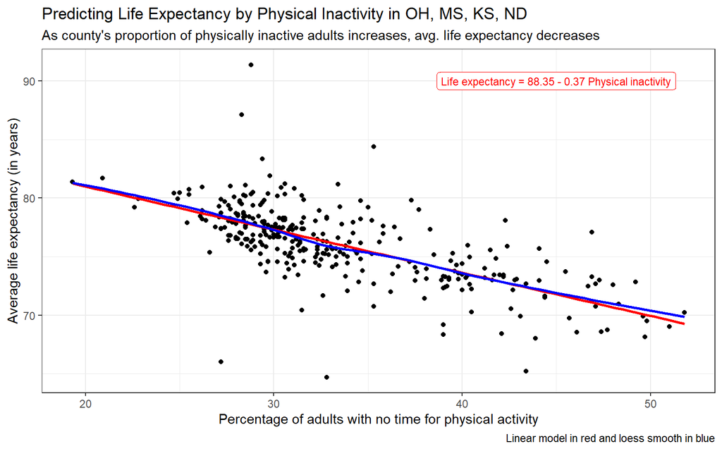

```r
analysis1 <- chr_2022 |> filter(complete.cases(physical_inactivity, life_expectancy, state))

analysis1_plot1 <- ggplot(data = analysis1, aes(x = physical_inactivity, y = life_expectancy)) +
  geom_point() +
  geom_smooth(method = "lm",se = FALSE, formula= y ~ x,  col = "red") +
  geom_smooth(method = "loess", se = FALSE, formula= y ~ x, col = "blue") +
  geom_label(aes(x = 45, y = 90,label = "Life expectancy = 88.35 - 0.37 Physical inactivity"), size = 3, color = "red") +
  labs(title = "Predicting Life Expectancy by Physical Inactivity in OH, MS, KS, ND",
subtitle= "As county's proportion of physically inactive adults increases, avg. life expectancy decreases",
       x = "Percentage of adults with no time for physical activity",
       y = "Average life expectancy (in years)",
       caption = "Linear model in red and loess smooth in blue")

analysis1_plot1
```

As a county’s proportion of adults with no leisure time for physical activity increases, the average life expectancy shortens, which seems like a negative association. Most of the data points are clustered to the straight line which indicates a moderate to strong negative association. The loess smooth line almost superimposes the straight line which tells us that a linear regression model might fit the data. However, there are a few outlier values further away from the general pattern.

## 6.4 Transformation Assessment

I have used the boxcox approach to identify which transformation on the Tukey’s ladder fit best for my model.

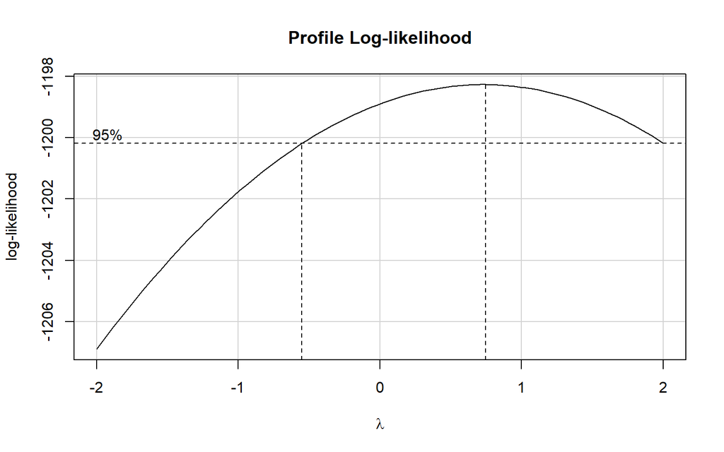

```r
boxCox(analysis1$life_expectancy ~ analysis1$physical_inactivity)
```

```r
powerTransform(analysis1$life_expectancy ~ analysis1$physical_inactivity)
```

```
Estimated transformation parameter
       Y1
0.7313174
```

The boxcox plot peaks at a lambda value of 0.73, which is more close to 1 but also close to 0.5. Based on Tukey’s ladder of power transformation, I have created a scatter plot of square root transformation for my outcome and compared it with my untransformed outcome.

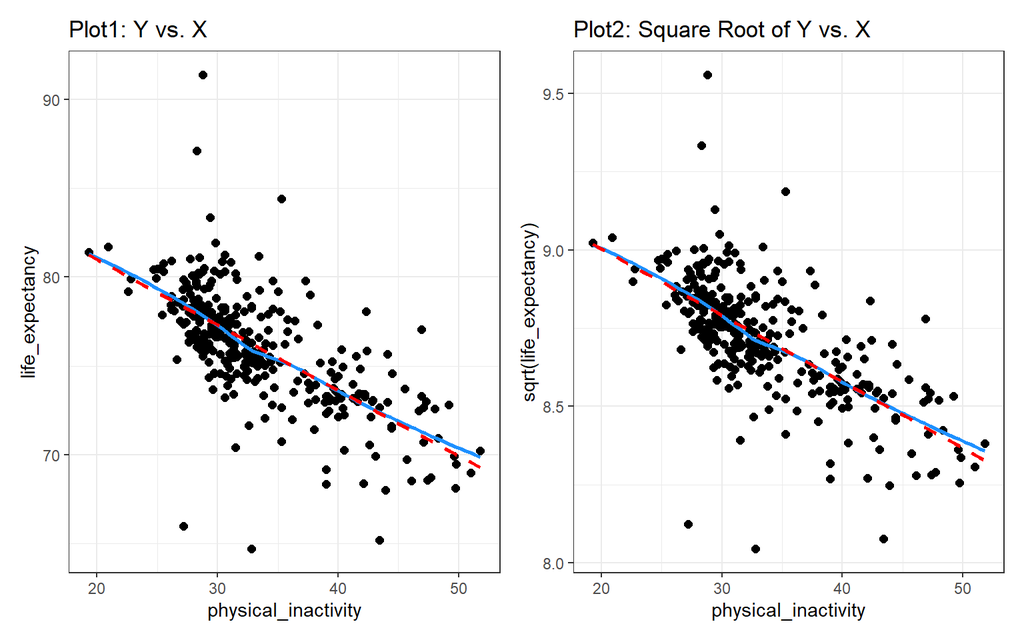

```r
p1 <- ggplot(analysis1, aes(x = physical_inactivity, y = life_expectancy)) +
    geom_point(size = 2) +
    geom_smooth(method = "loess", se = FALSE,
                formula = y ~ x, col = "dodgerblue") +
    geom_smooth(method = "lm", se = FALSE,
                formula = y ~ x, col = "red", linetype = "dashed") +
    labs(title = "Plot1: Y vs. X")

p2 <- ggplot(analysis1, aes(x = physical_inactivity, y = sqrt(life_expectancy))) +
    geom_point(size = 2) +
    geom_smooth(method = "loess", se = FALSE,
                formula = y ~ x, col = "dodgerblue") +
    geom_smooth(method = "lm", se = FALSE,
                formula = y ~ x, col = "red", linetype = "dashed") +
    labs(title = "Plot2: Square Root of Y vs. X")

p1 + p2
```

Since no other meaningful observation can be made through the square root transformation plot compared with the untransformed plot, I have decided to stick with my original version (untransformed) of the outcome.

## 6.5 The Fitted Model

### 6.5.1 The Prediction Equation

```r
analysis1_model <- lm(life_expectancy ~ physical_inactivity, data = analysis1)
extract_eq(analysis1_model, use_coefs = TRUE, coef_digits = 2)
```

$$\operatorname{\widehat{life\_expectancy}} = 88.35 -
0.37(\operatorname{physical\_inactivity})$$
The straight line model for these data fitted by least squares is life expectancy = 88.35 - 0.37 physical inactivity. The slope of physical inactivity is negative, which indicates that as the percentage of adults with no time for physical activity increases, we expect that average life expectancy decreases. Specifically, we expect that for every additional increase in % of adults with no time for physical activity, the average life expectancy will be 0.37 years shorter.

### 6.5.2 The Model Coefficients

```r
m1 <-lm(life_expectancy ~ physical_inactivity, data = analysis1)
tidy(m1, conf.int = TRUE, conf.level = 0.90) |>
 kable(dig=1) |> kable_styling(font_size = 18)
```

| term | estimate | std.error | statistic | p.value | conf.low | conf.high |
| --- | --- | --- | --- | --- | --- | --- |
| (Intercept) | 88.4 | 0.8 | 117.2 | 0 | 87.1 | 89.6 |
| physical_inactivity | -0.4 | 0.0 | -16.6 | 0 | -0.4 | -0.3 |

### 6.5.3 Summaries of Model Fit

```r
glance(m1) |>
  select(r.squared, adj.r.squared, sigma, nobs, df, df.residual) |>
   kbl(digits = c(4, 4, 3, 0, 0)) |> kable_styling(font_size = 18)
```

| r.squared | adj.r.squared | sigma | nobs | df | df.residual |
| --- | --- | --- | --- | --- | --- |
| 0.4636 | 0.4619 | 2.404 | 319 | 1 | 317 |

The R-squared (squared correlation coefficient) value for 319 observations is 0.463, which implies that 46.3% of the variation in life expectancy is explained using this linear model with physical inactivity. The residual standard error is 2.404 years.

## 6.6 Residual Analysis

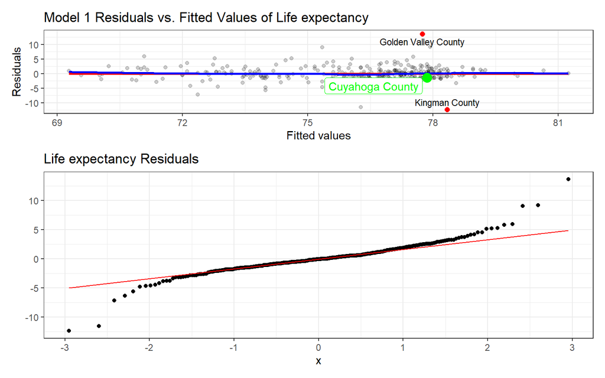

```r
analysis1_aug <- augment(analysis1_model, data = analysis1)

analysis1_plot2 <- ggplot(analysis1_aug, aes(x = .fitted, y = .resid)) +
  geom_point(alpha = 0.2) +
  geom_point(data=analysis1_aug |>
               slice_max(abs(.resid), n=2),
            col="red", size=2) +
  geom_text_repel(data = analysis1_aug |>
                    slice_max(abs(.resid), n = 2),
                  aes(label = county), size=3) +
  geom_smooth(method = "lm", col = "red",
              formula = y ~ x, se = FALSE) +
  geom_smooth(method = "loess", col = "blue",
              formula = y ~ x, se = FALSE) +
  geom_point(data = analysis1_aug |> filter(county == "Cuyahoga County"),
col = "green", size = 4) +
  geom_label_repel(data = analysis1_aug |> filter(county == "Cuyahoga County"),
aes(label = "Cuyahoga County"), col = "green") +
  labs(title = "Model 1 Residuals vs. Fitted Values of Life expectancy",
       x = "Fitted values", y = "Residuals")


analysis1_plot3 <- ggplot(analysis1_aug, aes(sample = .resid)) +
  geom_qq() + geom_qq_line(col = "red") +
  labs(title = "Life expectancy Residuals",
       y = "")

analysis1_plot2 / analysis1_plot3 + plot_layout(heights = c(1,2))
```

**Residual VS Fitted** - The data points are distributed above and below x-axis and but doesn’t appear to have a fuzzy football or curve shaped pattern. The variability is also pretty much the same throughout the plot. The residual plot doesn’t indicate if any of the assumptions about my model are false.

### 6.6.1 Prediction for Cuyahoga County, OH

```r
analysis1_aug |>
  filter(county == "Cuyahoga County") |>
  select(state, county, life_expectancy, .fitted, .resid, physical_inactivity) |>
  kable(digits = c(0,0,2,2,2,0)) |> kable_styling(font_size = 18)
```

| state | county | life_expectancy | .fitted | .resid | physical_inactivity |
| --- | --- | --- | --- | --- | --- |
| OH | Cuyahoga County | 76.49 | 77.86 | -1.37 | 28 |

For Cuyahoga county, Ohio, the actual value for life expectancy was 76.49 years and the fitted value that my model predicted was 77.86 years which is down by 1.37 years.

### 6.6.2 My Two Least Successfully Fit Counties

```r
analysis1_aug |>
filter(county %in% c("Golden Valley County","Kingman County")) |>
  select(county, state, physical_inactivity, life_expectancy, .fitted, .resid) |>
  kable(digits = c(0,0,2,2,2,0)) |> kable_styling(font_size = 18)
```

| county | state | physical_inactivity | life_expectancy | .fitted | .resid |
| --- | --- | --- | --- | --- | --- |
| Kingman County | KS | 27.2 | 66.00 | 78.34 | -12 |
| Golden Valley County | ND | 28.8 | 91.38 | 77.75 | 14 |

The linear model is least successful at predicting life_expectancy in Kingman County, Kansas and Golden Valley County, North Dakota. The fitted values are 78.34 and 77.75 years of age respectively, while their actual values are 66.00 and 91.38 years.

## 6.7 Conclusions and Limitations

My research question was- What is the nature of the association between physical inactivity and life expectancy, in 319 counties in the states of OH, MS, KS, ND? Using the linear model, it can be concluded that there is a negative association between physical inactivity and life expectancy. This implies that as the proportion of adults with no leisure time for physical activity increases, average life expectancy decreases. However, based on the R-squared value only 46% (which is quite low) of this variation in life expectancy can be explained using linear model with physical inactivity. Moreover, the 90% confidence interval (87.1, 89.6) for my point estimate for life expectancy mean i.e., 88.4, is quite close ranged, which clearly indicates that there is no zero. The residual plot also doesn’t indicate if any of the assumptions about my model are false.

There are certain limitations to my analysis. The sample size of my counties i.e., 319 is not large enough to represent the other counties in the Midwest of the United States. Population behavior could vary among different terrains in the Midwest, leading to different results in my regression analysis. For instance, factors like income and neighborhood may contribute as confounders. People with low income and poor neighborhood may not have adequate facilities like gym, side walks and parks in their locality, which eventually adds to physical inactivity.

# 7 Analysis 2

## 7.1 The Variables

In analysis 2, I will be using mhi_cat (variable 5) as my predictor to measure my outcome of interest i.e., life_expectancy (variable 1). The mhi_cat variable (multi-categorical predictor) indicates three levels of median household income (in $) i.e., low, middle and high. While, the life expectancy variable indicates the average number of years from birth a person can expect to live.

Using mosaic favstats, I have created a tibble for my outcome i.e., life expectancy in the four states KS, MS, ND and OH to check for complete cases.

```r
mosaic::favstats(life_expectancy ~ state, data = chr_2022) |>
    kable(dig=2) |> kable_styling(font_size = 18)
```

| state | min | Q1 | median | Q3 | max | mean | sd | n | missing |
| --- | --- | --- | --- | --- | --- | --- | --- | --- | --- |
| KS | 64.71 | 75.67 | 77.34 | 78.34 | 81.39 | 77.01 | 2.53 | 102 | 2 |
| MS | 68.03 | 72.16 | 73.18 | 74.27 | 79.21 | 73.04 | 2.40 | 81 | 1 |
| ND | 65.22 | 77.78 | 78.66 | 80.31 | 91.38 | 78.63 | 4.14 | 48 | 0 |
| OH | 70.75 | 75.23 | 76.50 | 77.49 | 81.72 | 76.37 | 2.00 | 88 | 0 |

In the four states of OH, MS, KS and ND, 319 counties have complete data for my outcome i.e., life expectancy.

Using tabyl and gt functions, I have created a table for my multi-category predictor i.e., mhi_cat segregating by all three categories in the four states KS, MS, ND and OH to check for complete cases.

```r
chr_2022 |>
tabyl(state, mhi_cat) |>
adorn_totals(where = c("row", "col")) |>
gt()|>
gt_theme_nytimes() |>
tab_header(title = "#Counties in MHI categories in states of KS, MS, ND and OH")
```

#Counties in MHI categories in states of KS, MS, ND and OH

| state | low | middle | high | Total |
| --- | --- | --- | --- | --- |
| KS | 17 | 53 | 34 | 104 |
| MS | 66 | 11 | 5 | 82 |
| ND | 5 | 16 | 27 | 48 |
| OH | 20 | 27 | 41 | 88 |
| Total | 108 | 107 | 107 | 322 |

In my four states, OH (88), KS (102), MS (81) and ND (48) have complete data on 319 counties for my multi category predictor (median household income) with three levels - low (107), middle (107) and high (105).

```r
chr_2022 |>
    filter(state == "OH") |>
    filter(county == "Cuyahoga County") |>
    select(state, county, life_expectancy, mhi_cat)|>
    kable(dig=2) |> kable_styling(font_size = 18)
```

| state | county | life_expectancy | mhi_cat |
| --- | --- | --- | --- |
| OH | Cuyahoga County | 76.49 | middle |

In Cuyahoga county, Ohio, the individuals with life expectancy of 76.48 years lies in middle MHI (median household income) category.

## 7.2 Research Question

Which of median household income categories is associated with the highest mean level of life expectancy, in 319 counties in the states of KS, MS, ND and OH?

## 7.3 Data Visualization

I have filtered complete cases and created analysis2. Since, only 3 counties have missing values for my outcome (i.e., life expectancy) which is quiet a small number, that is why, I decided not to impute the data. Using complete cases, I have created a violin box plot for my outcome and predictor.

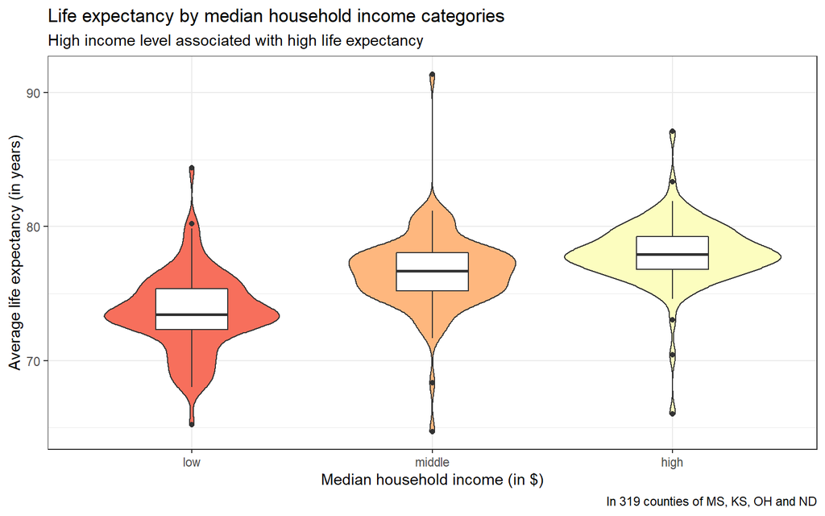

```r
analysis2 <- chr_2022 |> filter(complete.cases(median_household_income, life_expectancy, state))

analysis2_plot1 <- ggplot(data = analysis2, aes(x = mhi_cat, y = life_expectancy)) +
  geom_violin(aes(fill = mhi_cat)) +
  geom_boxplot(width = 0.3) +
  scale_fill_viridis_d(begin = 0.7, option = "A") +
  guides(fill = "none", col = "none") +
  labs(title = "Life expectancy by median household income categories",
       subtitle= "High income level associated with high life expectancy",
       caption = "In 319 counties of MS, KS, OH and ND",
       y = "Average life expectancy (in years)", x = "Median household income (in $)")

analysis2_plot1
```

The violin box plot shows the relationship between median household income categories and life expectancy. It shows the median value of low income category is the lowest, followed by middle income category and high median income level category. The high median household income category is associated with highest mean level of life expectancy. There are few outliers in all three categories.

## 7.4 The Fitted Model

### 7.4.1 The Prediction Equation

```r
analysis2_model <- lm(life_expectancy ~ mhi_cat, data = analysis2)
extract_eq(analysis2_model, wrap= TRUE, use_coefs = TRUE, coef_digits = 2)
```

$$\begin{aligned}
\operatorname{\widehat{life\_expectancy}} &= 73.63 +
2.98(\operatorname{mhi\_cat}_{\operatorname{middle}}) +
4.38(\operatorname{mhi\_cat}_{\operatorname{high}})
\end{aligned}$$

The straight line model for these data fitted by least squares is life expectancy = 73.63 + 2.98(mhi_cat_middle) + 4.38(mhi_cat_high). The slope of mhi_cat is positive, which indicates that as median household income increases, we expect that average life expectancy increases too. Specifically, we expect that for every additional increase in mhi_cat_middle, the average life expectancy will be 2.98 years longer. While, for additional increase in mhi_cat_high, the average life expectancy will increase by 4.38 years.

### 7.4.2 The Model Coefficients

```r
m2 <-lm(life_expectancy ~ mhi_cat, data = analysis2)
tidy(m2, conf.int = TRUE, conf.level = 0.90) |>
 kable(dig=1) |> kable_styling(font_size = 18)
```

| term | estimate | std.error | statistic | p.value | conf.low | conf.high |
| --- | --- | --- | --- | --- | --- | --- |
| (Intercept) | 73.6 | 0.3 | 279.1 | 0 | 73.2 | 74.1 |
| mhi_catmiddle | 3.0 | 0.4 | 8.0 | 0 | 2.4 | 3.6 |
| mhi_cathigh | 4.4 | 0.4 | 11.7 | 0 | 3.8 | 5.0 |

In m2, my point estimate for life expectancy mean is 73.6 and the slope of my predictor is positive, which implies that for every additional increase in mhi_cat_middle the prediction says that there is an expected increase in 3 years in life expectancy and the 90% confidence level around it is 2.4 and 3.6 years. Similarly for every additional increase in mhi_cat_high the prediction says that there is an expected increase in 4.4 years in life expectancy and the 90% confidence level around it is 3.8 and 5 years.

### 7.4.3 Summaries of Model Fit

```r
glance(m2) |>
  select(r.squared, sigma, nobs, df, df.residual) |>
   kbl(digits = c(4, 3, 0, 0, 0)) |> kable_styling(font_size = 18)
```

| r.squared | sigma | nobs | df | df.residual |
| --- | --- | --- | --- | --- |
| 0.3108 | 2.729 | 319 | 2 | 316 |

For 319 observations, the r-squared value for my model m2 is 0.3108, which means 31.08% of the variance in life expectancy among counties is predictable using the three income categories. The residual standard error for my prediction is 2.729 years.

## 7.5 Prediction Analysis

### 7.5.1 Residual Plot

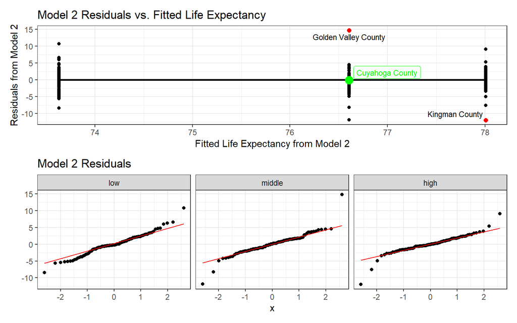

```r
analysis2_aug <- augment(analysis2_model, data = analysis2)

p1 <- ggplot(analysis2_aug, aes(x = .fitted, y = .resid)) +
  geom_point() +
  geom_smooth(method = "lm", formula = y ~ x, se = F,
               col = "black") +
  geom_point(data=analysis2_aug |>
               slice_max(abs(.resid), n=2),
            col="red", size=2) +
  geom_text_repel(data = analysis2_aug |>
                    slice_max(abs(.resid), n = 2),
                  aes(label = county), size=3) +
  geom_point(data = analysis2_aug |> filter(county == "Cuyahoga County"),
col = "green", size = 4) +
   geom_label_repel(data = analysis2_aug |> filter(county == "Cuyahoga County"),
aes(label = "Cuyahoga County"), col = "green", size = 3)+
  labs(title = "Model 2 Residuals vs. Fitted Life Expectancy",
       x = "Fitted Life Expectancy from Model 2",
       y = "Residuals from Model 2")

p2 <- ggplot(analysis2_aug, aes(sample = .resid)) +
  geom_qq() +
  geom_qq_line(col = "red") +
  facet_grid(~mhi_cat) +
  labs(title = "Model 2 Residuals",
       y = "")


p1 / p2
```

**Residual VS Fitted** - The data points are distributed above and below x-axis and don’t appear to have a fuzzy football or curve shaped pattern. The three different values of fitted life expectancy on the x- axis indicates the three categories of my predictor i.e., low, middle and high. The variability is also pretty much the same throughout the plot. There are two outliers, i.e., Golden Valley County and Kingman County, that are my model’s least successful predictions. In conclusion, not much can be interpreted from this residual plot.

### 7.5.2 Prediction for Cuyahoga County, OH

```r
analysis2_aug |>
  filter(county == "Cuyahoga County") |>
  select(state, county, life_expectancy, .fitted, .resid, mhi_cat) |>
  kable(digits = c(0,0,2,2,2,0)) |> kable_styling(font_size = 18)
```

| state | county | life_expectancy | .fitted | .resid | mhi_cat |
| --- | --- | --- | --- | --- | --- |
| OH | Cuyahoga County | 76.49 | 76.61 | -0.12 | middle |

Cuyahoga county, Ohio, lies in the middle MHI category with average life expectancy value of 76.49 years and the fitted value of the model is 76.61 which up by 0.12 years.

### 7.5.3 My Two Least Successfully Fit Counties

```r
analysis2_aug |>
filter(county %in% c("Golden Valley County","Kingman County")) |>
  select(county, state, mhi_cat, life_expectancy, .fitted, .resid) |>
  kable(digits = c(0,0,2,2,2,0)) |> kable_styling(font_size = 18)
```

| county | state | mhi_cat | life_expectancy | .fitted | .resid |
| --- | --- | --- | --- | --- | --- |
| Kingman County | KS | high | 66.00 | 78.01 | -12 |
| Golden Valley County | ND | middle | 91.38 | 76.61 | 15 |

The linear model is least successful at predicting life_expectancy in Kingman County, Kansas and Golden Valley County, North Dakota. The fitted values are 78.01 and 76.61 years of age respectively, while their actual values are 66.00 and 91.38 years.

## 7.6 Conclusion and Limitations

Since the sample size of my counties is 319, generalizing my interpretation for all the Midwestern counties in the United States is not a good idea. Factor like generational wealth may contribute as a confounder. Moreover, the geographical location, another confounder, may contribute to varied distribution of median household income in different states in the Midwest.

# 8 Analysis 3

## 8.1 The Variables

In analysis 3, I will be using some_college (variable 3) as my predictor to measure my outcome of interest i.e., life_expectancy (variable 1). The some_college variable (predictor) indicates the % of the population aged 25-44 with some post-secondary education While, the life expectancy variable indicates the average number of years from birth a person can expect to live.

```r
mosaic::favstats(life_expectancy ~ state, data = chr_2022) |>
    select(state, mean, n, missing) |>
    kable(dig=2) |> kable_styling(font_size = 18)
```

| state | mean | n | missing |
| --- | --- | --- | --- |
| KS | 77.01 | 102 | 2 |
| MS | 73.04 | 81 | 1 |
| ND | 78.63 | 48 | 0 |
| OH | 76.37 | 88 | 0 |

In the four states of OH, MS, KS and ND, 319 counties have complete data for my outcome i.e., life expectancy.

```r
mosaic::favstats(some_college ~ state, data = chr_2022) |>
    select(state, mean,n, missing) |>
    kable(dig=2) |> kable_styling(font_size = 18)
```

| state | mean | n | missing |
| --- | --- | --- | --- |
| KS | 65.16 | 104 | 0 |
| MS | 54.39 | 82 | 0 |
| ND | 69.33 | 48 | 0 |
| OH | 58.48 | 88 | 0 |

In the four states of OH, MS, KS and ND, 322 counties have complete data for my outcome i.e., some_college

```r
chr_2022 |>
    filter(state == "OH") |>
    filter(county == "Cuyahoga County") |>
    select(state, county, life_expectancy, some_college) |>
    kable(digits = 2) |> kable_styling(font_size = 18)
```

| state | county | life_expectancy | some_college |
| --- | --- | --- | --- |
| OH | Cuyahoga County | 76.49 | 69.99 |

In Cuyahoga county, Ohio, 69.9% of adult population has gone to some college with the population average life expectancy of 76.48 years.

## 8.2 Research Question

How well does some_college predict life expectancy after accounting for differences between the states of OH, KS, MS and ND?

## 8.3 Data Visualization

I have filtered complete cases and created analysis3. Since, only 3 counties have missing values for my outcome (i.e., life expectancy) which is quiet a small number, that is why, I decided not to impute the data. Using complete cases, I have created a scatter plot for my outcome and predictor for my four states.

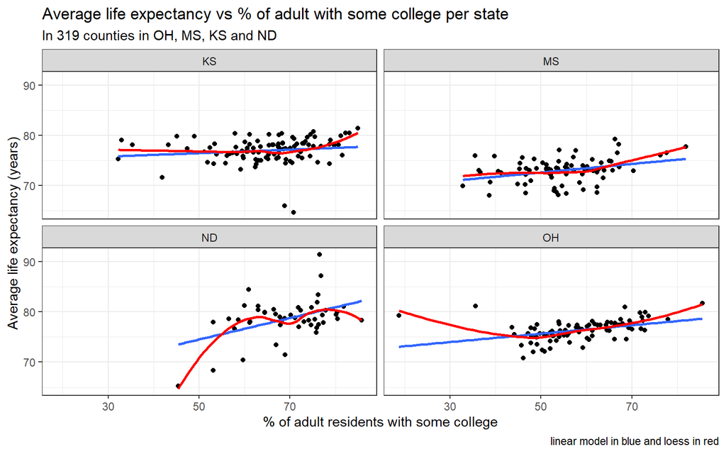

```r
analysis3 <- chr_2022 |> filter(complete.cases(some_college, life_expectancy, state))

ggplot(data = analysis3, aes(x = some_college, y = life_expectancy)) +
    geom_point() +
    geom_smooth(method = 'lm', formula = y ~ x, se = FALSE) +
    geom_smooth(method = 'loess', formula = y ~ x, color = 'red', se = FALSE) +
    labs(title = 'Average life expectancy vs % of adult with some college per state',
         subtitle= "In 319 counties in OH, MS, KS and ND",
         caption = "linear model in blue and loess in red",
        x = '% of adult residents with some college',
        y = 'Average life expectancy (years)') +
    facet_wrap( ~ state)
```

The scatter plot depicts the relationship of average life expectancy (outcome) with proportion of individuals who completed some college (quantitative predictor) in 319 counties in the states of OH, KS, MS and ND. Each state shows a positive linear relationship between some_college and life_expectancy but the slopes of my linear model are different in each states suggesting the magnitude of relationship varies across the four states.

## 8.4 The Fitted Model

### 8.4.1 The Prediction Equation

I have used fct_relevel function to to order my states, so that Ohio gets the baseline.

```r
analysis3 <- analysis3 %>% mutate(state = fct_relevel(state,
                                 "OH", "MS", "ND", "KS"))
analysis3_model <- lm(life_expectancy ~ some_college + state, data = analysis3)
extract_eq(analysis3_model, use_coefs = TRUE, coef_digits = 2)
```

[output not shown]

### 8.4.2 The Model Coefficients

```r
m3 <-lm(life_expectancy ~ some_college + state, data = analysis3)
tidy(m3, conf.int = TRUE, conf.level = 0.90) |>
 kable(dig=2) |> kable_styling(font_size = 18)
```

| term | estimate | std.error | statistic | p.value | conf.low | conf.high |
| --- | --- | --- | --- | --- | --- | --- |
| (Intercept) | 71.60 | 0.90 | 79.99 | 0.00 | 70.12 | 73.08 |
| some_college | 0.08 | 0.01 | 5.59 | 0.00 | 0.06 | 0.11 |
| stateMS | -3.02 | 0.40 | -7.60 | 0.00 | -3.68 | -2.37 |
| stateND | 1.37 | 0.49 | 2.83 | 0.00 | 0.57 | 2.17 |
| stateKS | 0.11 | 0.38 | 0.28 | 0.78 | -0.53 | 0.74 |

### 8.4.3 Summaries of Model Fit

```r
glance(m3) |>
  select(r.squared, sigma, nobs, df, df.residual) |>
   kbl(digits = c(4, 3, 0, 0, 0)) |> kable_styling(font_size = 18)
```

| r.squared | sigma | nobs | df | df.residual |
| --- | --- | --- | --- | --- |
| 0.3988 | 2.557 | 319 | 4 | 314 |

For 319 observations, the r-squared (squared correlation coefficient) value is 0.398, which implies that around 40% of the variation in life expectancy is explained using this linear model with some college. And, the residual standard error for my prediction is 2.55 years.

## 8.5 Residual Analysis

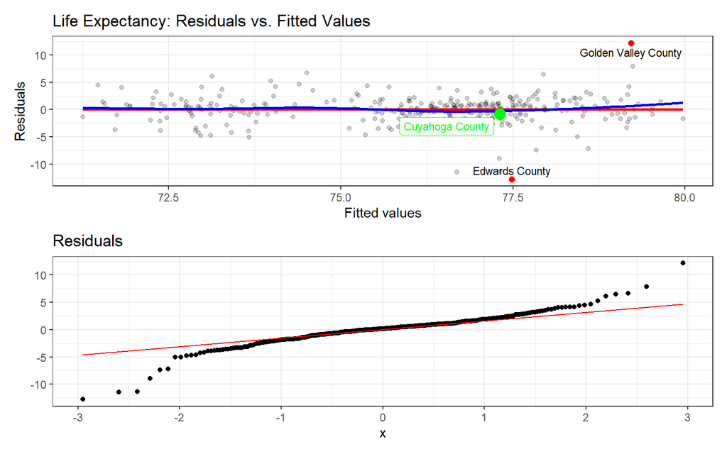

```r
analysis3_aug <- augment(analysis3_model, data = analysis3)

analysis3_plot2 <- ggplot(analysis3_aug, aes(x = .fitted, y = .resid)) +
  geom_point(alpha = 0.2) +
  geom_smooth(method = "lm", col = "red",
              formula = y ~ x, se = FALSE) +
  geom_smooth(method = "loess", col = "blue",
              formula = y ~ x, se = FALSE) +
  geom_point(data=analysis3_aug |>
               slice_max(abs(.resid), n=2),
            col="red", size=2) +
  geom_text_repel(data = analysis3_aug |>
                    slice_max(abs(.resid), n = 2),
                  aes(label = county), size=3) +
  geom_point(data = analysis3_aug |> filter(county == "Cuyahoga County"),
col = "green", size = 4) +
   geom_label_repel(data = analysis3_aug |> filter(county == "Cuyahoga County"),
aes(label = "Cuyahoga County"), col = "green", size = 3)+
  labs(title = "Life Expectancy: Residuals vs. Fitted Values",
       x = "Fitted values", y = "Residuals")


analysis3_plot3 <- ggplot(analysis3_aug, aes(sample = .resid)) +
  geom_qq() + geom_qq_line(col = "red") +
  labs(title = "Residuals",
       y = "")

analysis3_plot2 / analysis3_plot3
```

**Residual VS Fitted** - The data points are distributed above and below x-axis and don’t appear to have a fuzzy football or curve shaped pattern. Majority of data points are clustered in the right half (between 75.0 and 80.0) of the plot. The variability is also pretty much the same throughout the plot, with a few outliers. The residual plot doesn’t indicate if any of the assumptions about my model are false.

### 8.5.1 Prediction for Cuyahoga County, OH

```r
analysis3_aug |>
  filter(county == "Cuyahoga County") |>
  select(state, county, life_expectancy, .fitted, .resid, some_college) |>
  kable(digits = c(0,0,2,2,2,0)) |> kable_styling(font_size = 18)
```

| state | county | life_expectancy | .fitted | .resid | some_college |
| --- | --- | --- | --- | --- | --- |
| OH | Cuyahoga County | 76.49 | 77.31 | -0.82 | 70 |

In Cuyahoga county, Ohio, the average life expectancy value is 76.49 years and the fitted value of the model is 77.31 which down by 0.82 years.

### 8.5.2 My Two Least Successfully Fit Counties

```r
analysis3_aug |>
filter(county %in% c("Golden Valley County","Edwards County")) |>
  select(county, state, some_college, life_expectancy, .fitted, .resid) |>
  kable(digits = c(0,0,2,2,2,0)) |> kable_styling(font_size = 18)
```

| county | state | some_college | life_expectancy | .fitted | .resid |
| --- | --- | --- | --- | --- | --- |
| Edwards County | KS | 70.80 | 64.71 | 77.48 | -13 |
| Golden Valley County | ND | 76.49 | 91.38 | 79.21 | 12 |

## 8.6 Conclusions and Limitations

My research question was- How well does some_college predict life expectancy after accounting for differences between the states of OH, KS, MS and ND? The scatter plot depicts a positive linear relationship between some_college and life_expectancy in all four states. However, the slope of linear model in all four states varies greatly. The r-squared value explains only 40% variation in my data.

There are several limitations in my analysis. The sample size is small and by looking at the scatter plot in each state, it is clear that the magnitude of relationship varies greatly in all four states. This suggests that this interpretation might not hold true for all other counties in the Midwestern region. Confounders like income, generational wealth and neighborhood may also contribute to this variation. For example, residents with high income could afford college while residents with low income may not.

# 10 One Last Note from Dr. Love

Note that there is [a checklist for the final report](https://thomaselove.github.io/431-projectA-2022/check_final.html) as part of the [Examples & Hints page](https://thomaselove.github.io/431-projectA-2022/check_final.html) that includes many things we’ll be looking for in grading. It’s well worth your time to review the checklist before submitting your work.

- And hit F7 in RStudio to run a spell-check, too!
- Also, be sure to delete this section (Section 10) before submitting your work.